# Untitled

## Q1

Samsung has produced the most number of mobiles.

```r
mobile <- read_csv("~/Desktop/mobile_data.csv")
topone <- tail(names(sort(table(mobile$company))), 1)
topone
```

```
[1] "Samsung"
```

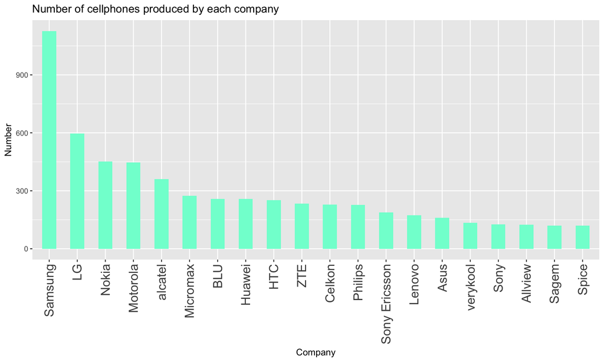

```r
toptwenty <- head(sort(table(mobile$company), decreasing = TRUE), 20)
p = ggplot(data = data.frame(toptwenty), aes(x = Var1,y = Freq))
p + geom_bar(stat = "identity", width = 0.5, fill = "aquamarine") + xlab("Company")+ ylab("Number")+ ggtitle("Number of cellphones produced by each company") + theme(axis.text.x=element_text(angle=90,hjust=1,vjust=0.5,size = 15))
```

## Q2

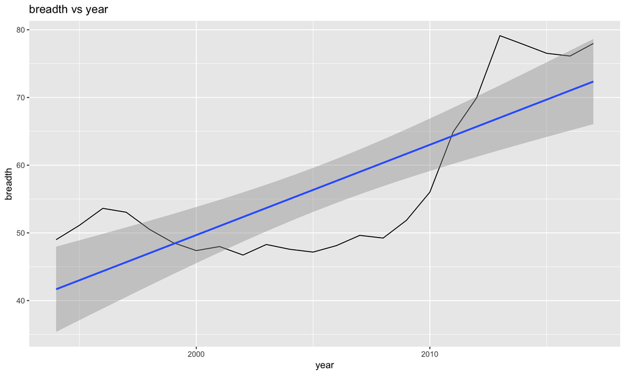

```r
mobile <- read_csv("~/Desktop/mobile_data.csv")
mob_br <- mobile %>% group_by(year) %>% summarise(breadth = mean(dim_breadth, na.rm = T))
breadth = ggplot(mob_br) + geom_line(aes(x = year, y = breadth)) + geom_smooth(aes(x = year, y= breadth), method = "lm") + ggtitle("breadth vs year")
breadth
```

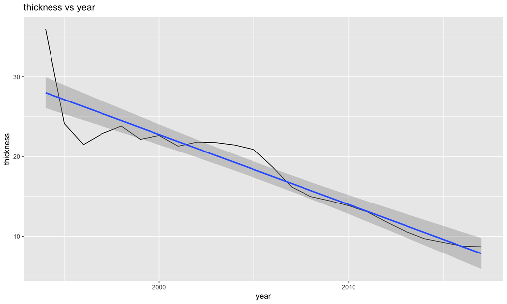

```r
mob_th <- mobile %>% group_by(year) %>% summarise(thickness = mean(dim_thickness, na.rm = T))
thick = ggplot(mob_th) + geom_line(aes(x = year, y = thickness))  + geom_smooth(aes(x = year, y= thickness), method = "lm") + ggtitle("thickness vs year")
thick
```

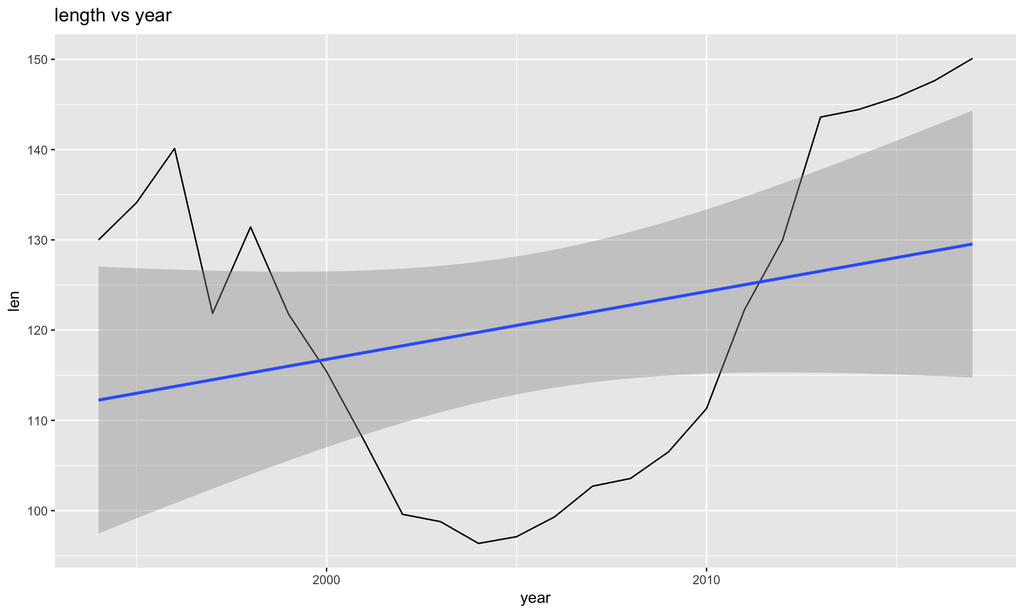

```r
mob_ln <- mobile %>% group_by(year) %>% summarise(len = mean(dim_length, na.rm = T))
length = ggplot(mob_ln) + geom_line(aes(x = year, y = len))  + geom_smooth(aes(x = year, y= len), method = "lm") + ggtitle("length vs year")
length
```

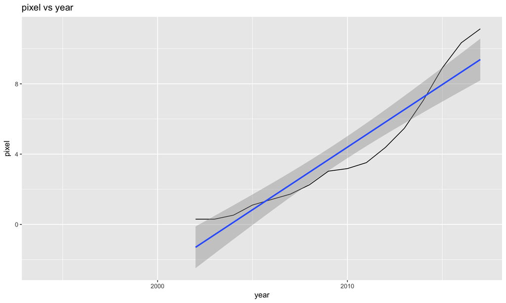

```r
mob_cam <- mobile %>% group_by(year) %>% summarise(pixel = mean(cam_px, na.rm = T))
camera = ggplot(mob_cam) + geom_line(aes(x = year, y = pixel))  + geom_smooth(aes(x = year, y= pixel), method = "lm") + ggtitle("pixel vs year")
camera
```

## Q3

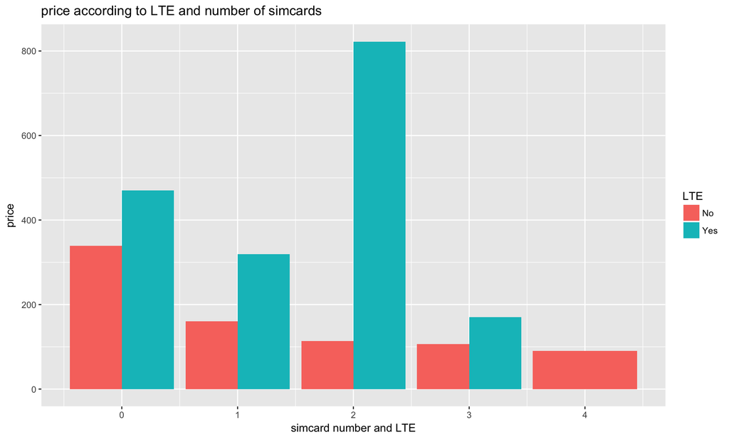

```r
mobile <- read_csv("~/Desktop/mobile_data.csv")
mob_simnumber <- mobile  %>% group_by(sim_no,LTE) %>% summarise(price = mean(price, na.rm = T))
simcard <- ggplot(mob_simnumber)+ geom_bar(aes(x = sim_no, y = price, fill = LTE),position = "dodge", stat = "identity") + xlab("simcard number and LTE") +ggtitle("price according to LTE and number of simcards")
simcard
```

## Q4

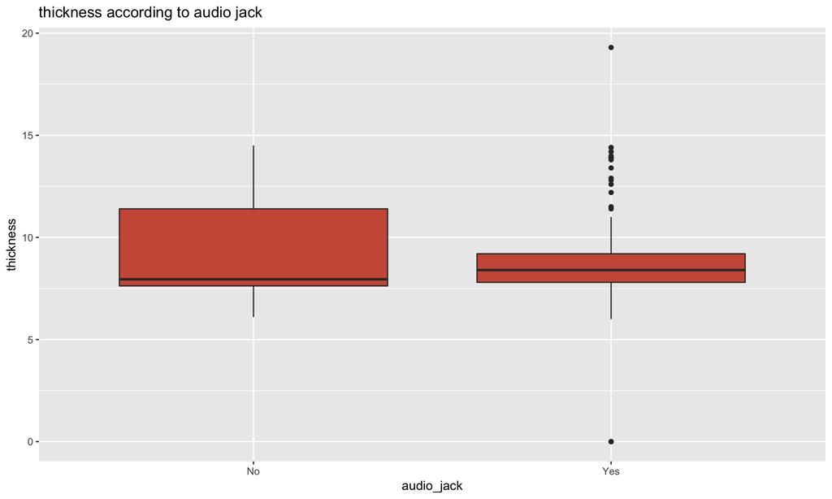

```r
mobile <- read_csv("~/Desktop/mobile_data.csv")
mobile2017 <- filter(mobile, year == 2017)
jackprthick <- ggplot(mobile2017) + geom_boxplot(aes(x = audio_jack, y = dim_thickness), fill = "coral3") + ylab("thickness") + ggtitle("thickness according to audio jack")
jackprthick
```

## Q5

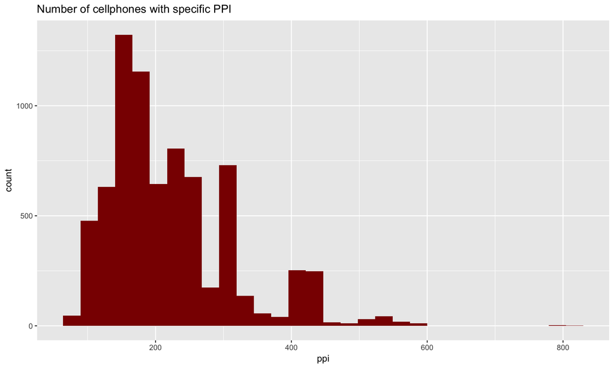

```r
mobile <- read_csv("~/Desktop/mobile_data.csv")
ppimobile <- mobile %>% mutate(ppi = sqrt(px_row^2  + px_col^2) / display_size)
ppigraph <- ggplot(ppimobile) + geom_histogram(aes(x = ppi), fill = "darkred") +ggtitle("Number of cellphones with specific PPI")
ppigraph
```

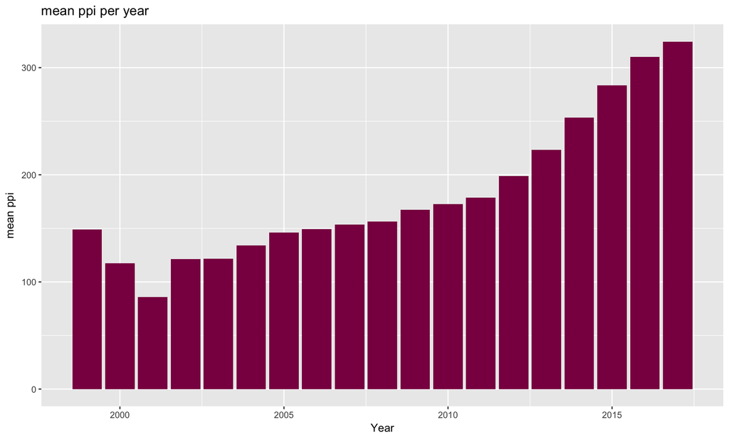

```r
ppiyear <- ppimobile %>% group_by(year) %>% summarise(ppiperyear = mean(ppi, na.rm = T) )
ppiperyeargraph <- ggplot(ppiyear) + geom_bar(aes(x = year, y = ppiperyear),stat = "identity", fill = "deeppink4") +
  xlab("Year") + ylab("mean ppi") + ggtitle("mean ppi per year")
ppiperyeargraph
```

```r
themostppi <- ppimobile %>% arrange(desc(ppi)) %>% head(1)
themostppi$device
```

```
[1] "Xperia XZ Premium"
```

## Q6

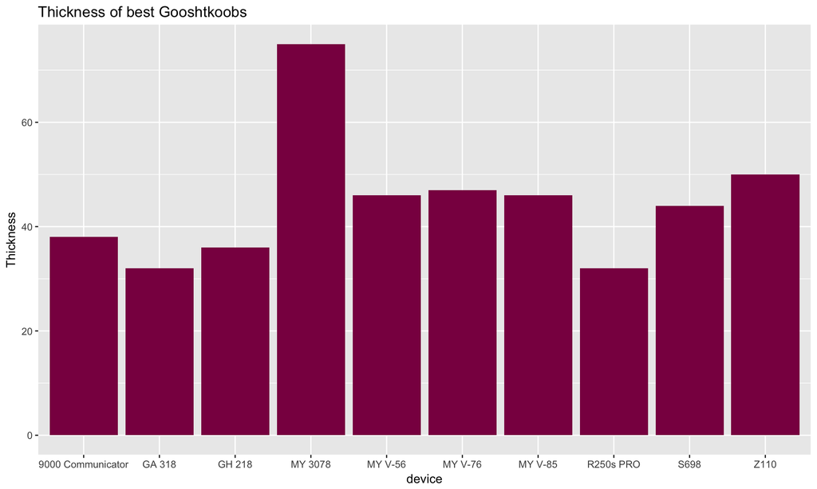

```r
mobile <- read_csv("~/Desktop/mobile_data.csv")
gooshtkoobmobile <- filter(mobile, dim_thickness > 25)
sorted <- gooshtkoobmobile %>% arrange(desc(dim_thickness)) %>% head(10) %>% mutate(name = device)
gooshtkoobgraph <- ggplot(sorted) + geom_bar(aes(x = name, y = dim_thickness), stat = "identity", fill = "deeppink4") + xlab("device")+ ylab("Thickness") + ggtitle("Thickness of best Gooshtkoobs")
gooshtkoobgraph
```

## Q7

```r
mobile <- read_csv("~/Desktop/mobile_data.csv")
mobiledensity <- mobile %>% mutate(density = weight * 1000 / (dim_thickness * dim_breadth * dim_length))
nrow(filter(mobiledensity, density < 1))
```

```
[1] 1014
```

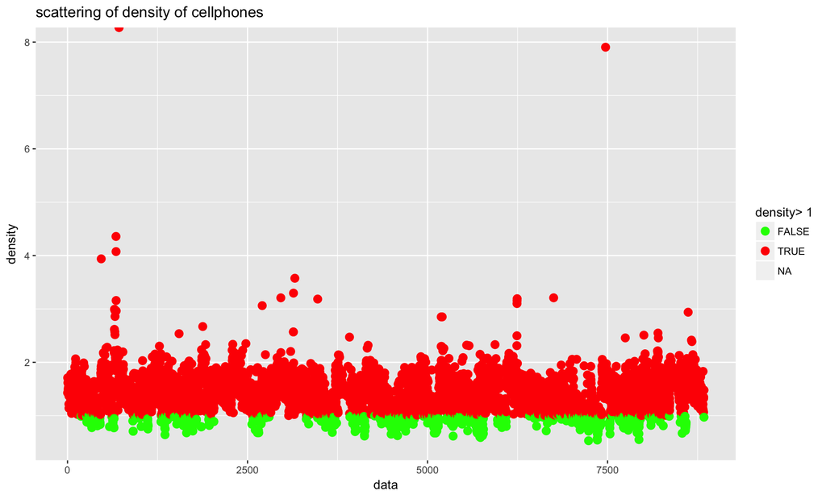

```r
mobiledensitygraph <- ggplot(mobiledensity) + geom_point(aes(x = 1:nrow(mobile) ,y = density, color = density > 1), na.rm = T, size = 3) + scale_colour_manual(name = 'density> 1', values = setNames(c('red','green'),c(T, F))) +
  xlab('data') + ylab('density') +ggtitle("scattering of density of cellphones")
mobiledensitygraph
```

## Q8

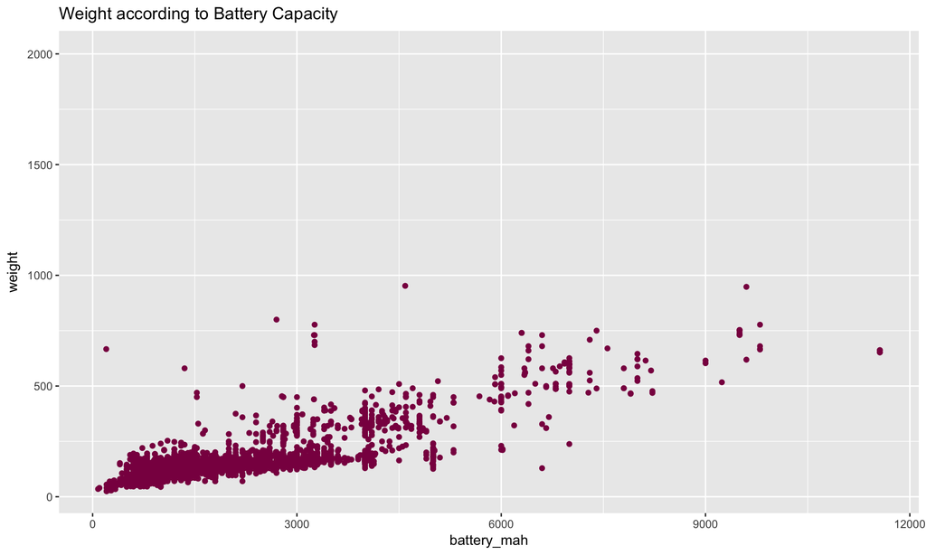

```r
mobile <- read_csv("~/Desktop/mobile_data.csv")
batteryvsweight <- ggplot(mobile) + geom_point(aes(x = battery_mah, y = weight), na.rm = T,color = "deeppink4") + ggtitle("Weight according to Battery Capacity")
batteryvsweight
```

```r
cor(mobile$battery_mah, mobile$weight, use = "complete.obs")
```

```
[1] 0.8086273
```

## Q9

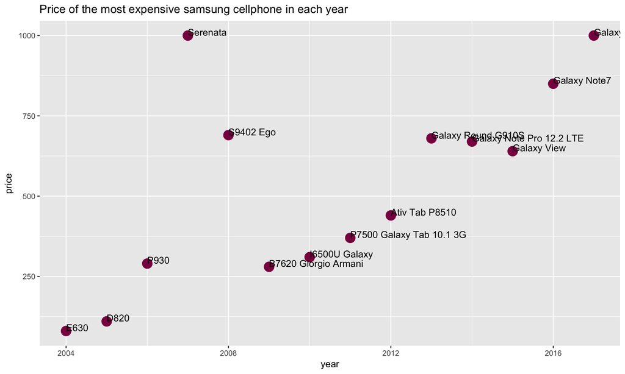

```r
mobile <- read_csv("~/Desktop/mobile_data.csv")
samsungmobile <- filter(mobile, company == "Samsung")
parchamperyear <- samsungmobile %>% group_by(year) %>% slice(which.max(price)) %>% mutate(device)
pricetimegraph <- ggplot(parchamperyear) + geom_point(aes(x = year, y = price, label = device), size = 5, color = "deeppink4") + ggtitle("Price of the most expensive samsung cellphone in each year") + geom_text(aes(x = year, y = price, label=device),hjust=0, vjust=0)
pricetimegraph
```

## Q10

نمودار اول نمودار متوسط قیمت گوشی در هر سال است که میبینیم در ابتدای قرن ۲۰ام بسیار زیاد بوده است سپس کاهش چشمگیر داشته و دوباره افزایش داشته است. این نمودار از این منظر جالب است که علت کاهش اولیه احتمالا پیدایش تکنولوژی های اولیه و پیشرفت انسان در زمینه ی ترانزیستورها و غیره بوده است اما افزایش دوباره احتمالا به علت پیدایش تکنولوژی های جدید مانند سیستم عامل صفحه نمایش لمسی و غیره ایجاد شده است. نمودار دوم ۱۰ کمپانی با گران قیمت ترین گوشی های همراه را نشان میدهد که نکته جالب در ان این است که بسیاری از شرکت ها در زمینه ی تلفن همراه خیلی شناخته شده نیستند. نمودار سوم رشد کیفیت دوربین های سلفی و دوربین گوشی را نشان میدهد که میبینیم دوربین سلفی در سال های اخیر با شیب بیشتری رشد داشته است و به طور کلی به نظر میرسد همه ی شرکت ها تمرکز زیادی روی بالا بردن کیفیت دوربین های خود گذاشته اند.

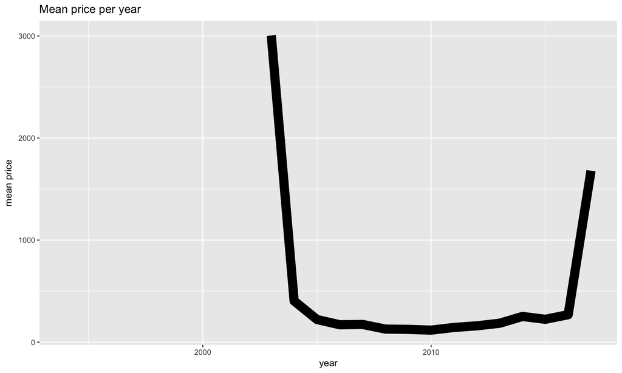

```r
mobile <- read_csv("~/Desktop/mobile_data.csv")
meanpriceperyear <- mobile %>% group_by(year) %>% summarise(priceperyear = mean(price,na.rm = T))
meanpriceperyeargraph <- ggplot(meanpriceperyear) + geom_line(aes(x = year, y = priceperyear),size = 5) + xlab("year") + ylab("mean price") + ggtitle("Mean price per year")
meanpriceperyeargraph
```

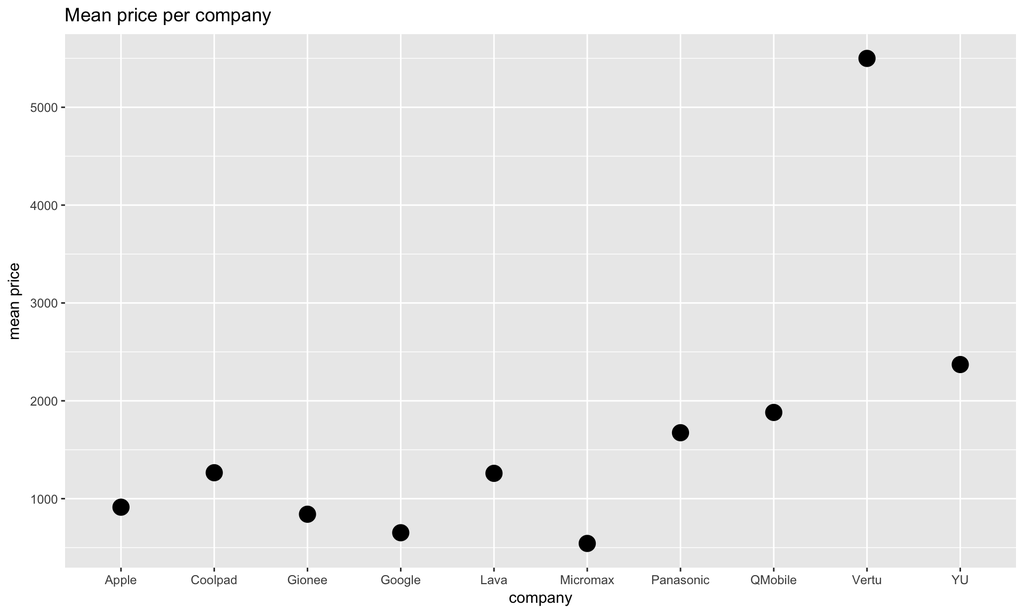

```r
meanpricepercomany <- mobile %>% group_by(company) %>% summarise(pricepercompany = mean(price,na.rm = T)) %>% arrange(desc(pricepercompany)) %>% head(10)
meanpricepercomgraph <- ggplot(meanpricepercomany) + geom_point(aes(x = company, y = pricepercompany),size = 5) + xlab("company") + ylab("mean price") + ggtitle("Mean price per company")
meanpricepercomgraph
```

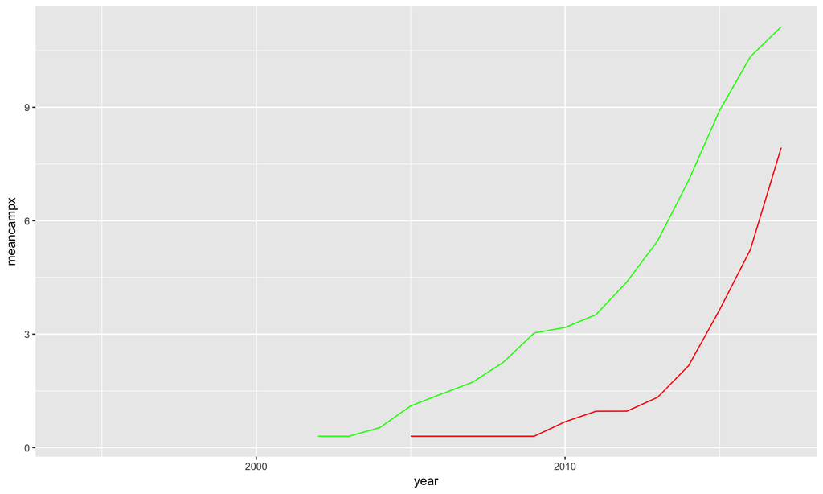

```r
campx <- mobile %>% group_by(year) %>% summarise(meancampx = mean(cam_px, na.rm = T))
selpx <- mobile %>% group_by(year) %>% summarise(meanselpx = mean(sel_px, na.rm = T))
ggplot() +
geom_line(data=campx, aes(x=year, y=meancampx,label = "camera pixel"), color='green') +
geom_line(data=selpx, aes(x=year, y=meanselpx), color='red', label= "selfie pixel")
```